# Warmup Exercise: refactoring prepIJDF function

Mae Hutchison

2026-05-30

# Task

Refactor the `prepIJDf` function from the Italy Migration example from GISC 7310 (week 12).

*Priorities:*  
- keep as an `s3` method  
- minimize package dependencies (ideally none)  
- code should be easy to follow for students seeing it for the first time  
- code should be structured in a way that is easy to maintain/make future updates

# Refactored prepIJDF function

The refactored function takes the same inputs and returns the same outputs as the original function. The only added functionality is some additional stop conditions that provide a descriptive error message to the student if an invalid argument is passed (also prevents unexpected behavior from unanticipated inputs). No dependencies were added.

*Optimization*: defined a helper function `expand_column_to_od` that can be applied to the input dataframe using `lapply`, avoiding the `for` loop of the original function.

*Organization*: condensed the transformation logic to `if`/`else` statement at the beginning to improve readability. Also moved `ID.ij` assignment to helper function `make_pair_id` to provide additional details in comments without cluttering the main function; also allows students to play around with the pair id function by itself to better understand it.

*Maintainability*: changed a few `if`/`else` blocks to assignment statements (e.g., now `$mij` is assigned only once overall, instead of once in each condition block). Also changed any un-ordered, multi-line lists to delimiter first (leading comma) for cleaner version control diffs.

*Style*: Changed all camel case varnames to snake case (except for input options).

*Documentation*: expanded the function description comment for clarity.

```r
new_prepIJDf <- function(df, mij=NULL, dij=NULL, logTrans=FALSE, zTrans=FALSE){
  ##############################################################################
  ## Build a long-format origin-destination (OD) dataframe from a wide-format
  ## input dataframe, expanding every variable into origin (.i), destination (.j)
  ## and log-ratio (.ijL) columns for all n^2 OD pairs.
  ##
  ## Arguments:
  ##   df        - dataframe with n rows, one per location. Each column is
  ##               expanded into OD pair format.
  ##   mij       - optional n x n list of migration flows. If NULL,
  ##               the mij column is set to NA.
  ##   dij       - optional n x n numeric matrix of distances or costs between
  ##               locations. If NULL, the dij column is omitted.
  ##   logTrans  - logical boolean flag indicating if numeric variables are to
  ##               be log-transformed.
  ##   zTrans    - logical boolean flag indicating if numeric variables are to
  ##               be standardized (scale of -1 to 1)
  ## Indices:
  ##           '.i'    for origin
  ##           '.j'    for destination
  ##           '.ij'   for origin/destination ratio
  ##           '.ijF'  factor variable
  ##           '.ijL'  log-transformed variable
  ##           '.ijLZ' log- and z-transformed variable
  ##           '.ijZ'  z-transformed variable
  ##############################################################################
  stopifnot(
     "df must be a dataframe" = is.data.frame(df)
    ,"logTrans must be a logical boolean" = is.logical(logTrans)
    ,"zTrans must be a logical boolean" = is.logical(zTrans)
    ,"mij must be a matrix or data frame of size n x n" =
        is.null(mij) ||
        ((is.matrix(mij) || is.data.frame(mij)) && all(dim(mij) == nrow(df)))
    ,"dij must be a numeric array of size n x n"=
        is.null(dij) ||
        (is.double(dij) && all.equal(dim(dij),rep(nrow(df),2)))
  )

  transform <- if(logTrans&&zTrans){
    "log.standard"
  }else if(logTrans){
    "log"
  }else if(zTrans){
    "standard"
  }else{
    "none"
  }

  ## Setup origin and destination ids and unique record id with the format:
  ## 'ij' for n < 10, iijj' for n < 100 and 'iiijjj' for n < 1000 etc.
  pairs <- expand.grid(i = 1:nrow(df), j = 1:nrow(df))
  od_df <- data.frame(
    ID.i  = pairs$i,
    ID.j  = pairs$j,
    ID.ij = make_pair_id(pairs$i, pairs$j)
  )

  ## Add vectorized migration flows
  od_df$mij <- if (is.null(mij)) {
    NA
  } else {
    as.vector(as.matrix(mij))
  }

  ## Add vectorized distances
  od_df$dij <- if(is.null(dij)){
    NA
  } else {
    as.vector(as.matrix(dij, nrow=nrow(dij)^2))
  }

  ## Cycle over all variables
  od_vars <- lapply(names(df), expand_column_to_od, df = df, transform=transform)

  ## Combine all variables into one data frame
  od_df    <- do.call(data.frame, c(list(od_df), od_vars))

  return(od_df)
} #end::prepIJDf
```

## Helper functions

```r
make_pair_id <- function(i, j, n=max(c(i, j))) {
  ##############################################################################
  ## Helper function to create pair IDs of every combination of vectors i and j
  ## i, j are integer vectors
  ## n: the upper bound of i & j, used to set digit-width so IDs don't collide.
  ##    Default max(i,j) but should be set explicitly when i/j may be a subset
  ##    of their full range.
  ## ex: 'ij' for n < 10, iijj' for n < 100 and 'iiijjj' for n < 1000 etc.
  ##############################################################################
  stopifnot(  "i must be an integer vector"=is.integer(i)
            , "j must be an integer vector"=is.integer(j)
            , "n must be a single positive integer"
               =(is.integer(n) && (n>0) && length(n) == 1)
            )
  digits <- trunc(log10(n) + 1)
  return(i * 10^digits + j)
}# end::make_pair_id


expand_column_to_od <- function(col_name, df, transform) {
  ##############################################################################
  ## Helper function to process one column of a dataframe to ij format
  ## col_name is the column name corresponding to column in df to process
  ## df is the data frame with the source data to process
  ## transform is a string 'log', 'standard', 'log.standard', or 'none'
  ##############################################################################
  stopifnot("transform must be str 'log', 'standard', 'log.standard', or 'none'"
            = transform %in% c("log", "standard", "log.standard", "none")
            , "df must be a data frame" = is.data.frame(df)
            , "col_name muse be a column name in df" = col_name %in% names(df)
            )

  col    <- df[[col_name]] # column of interest
  od_vec <- expand.grid(col, col) # origin-destination vector

  if (is.factor(col)) { # for factor columns, only make ij pairs
    col_levels <- levels(df[[col_name]])
    od_var <- data.frame(
      i = factor(od_vec[, 1], labels = col_levels),
      j = factor(od_vec[, 2], labels = col_levels)
    )
    names(od_var) <- c(paste0(col_name, ".iF"), paste0(col_name, ".jF"))
  } else { # for numeric columns, make ij pairs and log ratio,
           # and apply any transformations
    i_col  <- od_vec[, 1]
    j_col  <- od_vec[, 2]
    is_log      <- transform %in% c("log", "log.standard")
    is_standard <- transform %in% c("standard", "log.standard")
    all_positive <- !any(df[[col_name]] <= 0)

    od_var <- if (all_positive) {
      data.frame(
        i   = if (is_log) log(i_col) else i_col,
        j   = if (is_log) log(j_col) else j_col,
        ratio = log(i_col / j_col)
      )
    } else {
      # non-positive numeric variables will only generate ij pairs,
      # ignores any log transformation setting passed to `transform`
      data.frame(i = i_col, j = j_col)
    }

    if (is_standard) {
      od_var <- as.data.frame(scale(od_var))
    }

    suffix <- switch(transform,
                     "log"          = c(".iL",  ".jL",  ".ijL"),
                     "standard"     = c(".iZ",  ".jZ",  ".ijLZ"),
                     "log.standard" = c(".iLZ", ".jLZ", ".ijLZ"),
                     "none"         = c(".i",   ".j",   ".ijL")
    )

    names(od_var) <- paste0(col_name, suffix[seq_len(ncol(od_var))])
  } # end::numeric columns

  return(od_var)
} # end::expand_column_to_od
```

## Performance

```r
set.seed(37)
inputs <- make_synthetic_inputs(n = 100)
df  <- inputs$df
mij <- inputs$mij
dij <- inputs$dij

results <- bench::mark(
  previous = prev_prepIJDf(df, mij = mij, dij = dij, logTrans = TRUE, zTrans = TRUE),
  new = new_prepIJDf(df, mij = mij, dij = dij, logTrans = TRUE, zTrans = TRUE),
  iterations = 100,
  check = TRUE
)

print(results)
```

```
## # A tibble: 2 × 13
##   expression      min median `itr/sec` mem_alloc `gc/sec` n_itr  n_gc total_time
##   <bch:expr> <bch:tm> <bch:>     <dbl> <bch:byt>    <dbl> <int> <dbl>   <bch:tm>
## 1 previous     21.1ms 21.9ms      45.5    16.7MB     54.4    46    55      1.01s
## 2 new          19.2ms 19.9ms      48.1    16.3MB     56.3    47    55   977.29ms
## # ℹ 4 more variables: result <list>, memory <list>, time <list>, gc <list>
```

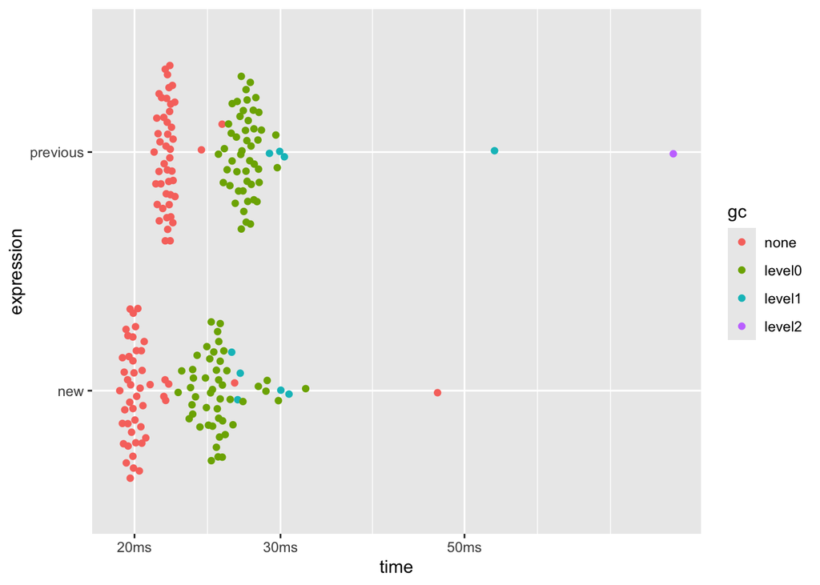

```r
plot(results)
```

# Alternative: build_od_pairs

I also made a modified version the `prepIJDf` function called `build_od_pairs`. This function removes the `ID.ij` index (forces student to use both `ID.i` and `ID.j` columns to reference unique rows), and sets rows where `i==j` to `NA` (throws an error if student forgets to account for diagonal elements, except for in `glm` functions where now the correct behavior (ignoring the diagonals) happens by default due to `na.action` being set to omit `NA`).

It also simplifies the transformation option input by passing a descriptive string instead of combo of two booleans.

```r
build_od_pairs <- function(df, mij = NULL, dij = NULL, transform = "none") {
  ##############################################################################
  ## Build a long-format origin-destination (OD) dataframe from a wide-format
  ## input dataframe, expanding every variable into origin (.i), destination (.j)
  ## and ratio (.ij) columns for all n^2 OD pairs.
  ##
  ## Arguments:
  ##   df        - dataframe with n rows, one per location. Each column is
  ##               expanded into OD pair format.
  ##   mij       - optional n x n numeric matrix of migration flows. If NULL,
  ##               the mij column is set to NA.
  ##   dij       - optional n x n numeric matrix of distances or costs between
  ##               locations. If NULL, the dij column is omitted.
  ##   transform - character string controlling variable transformation.
  ##               One of:
  ##                 "none"         : no transformation (default)
  ##                 "log"          : log-transform i, j, and ij columns
  ##                 "standard"     : z-standardize i, j, and ij columns
  ##                 "log.standard" : log-transform then z-standardize
  ##
  ## Returns:
  ##   A dataframe with n^2 rows, one per OD pair, containing:
  ##     ID.i, ID.j  - integer indices of origin and destination
  ##     mij         - migration flow (if provided)
  ##     dij         - distance/cost (if provided)
  ##     <var>.i     - origin value for each variable in df
  ##     <var>.j     - destination value for each variable in df
  ##     <var>.ijL    - log ratio of origin to destination (positive vars only)
  ##    * all od pairs where i=j have a value set to NA to prevent accidental use*
  ##
  ## Column suffixes:
  ##   .i    origin value
  ##   .j    destination value
  ##   .ijL  log ratio (origin / destination)
  ##   .iF   origin factor
  ##   .jF   destination factor
  ##   .iL   log-transformed origin
  ##   .jL   log-transformed destination
  ##   .iZ   z-standardized origin
  ##   .jZ   z-standardized destination
  ##   .iLZ  log- and z-transformed origin
  ##   .jLZ  log- and z-transformed destination
  ##   .ijLZ log- and z-transformed destination
  ##############################################################################
  stopifnot("df must be a dataframe" = is.data.frame(df)
            ,"mij must be a numeric matrix of size n x n"
             = is.null(mij) ||
               (is.matrix(mij) && all.equal(dim(mij),rep(nrow(df),2)))
            ,"dij must be a numeric matrix of size n x n"
             = is.null(dij) ||
               (is.matrix(dij) && all.equal(dim(dij),rep(nrow(df),2)))
            ,"transform must be str 'log', 'standard', 'log.standard', or 'none'"
             = transform %in% c("log", "standard", "log.standard", "none")
  )


  ## Setup origin and destination ids
  pairs <- expand.grid(i = 1:nrow(df), j = 1:nrow(df))
  od_df <- data.frame(ID.i=pairs$i, ID.j=pairs$j)

  ## Add vectorized migration flows
  od_df$mij <- if (is.null(mij)) {NA} else {as.vector(mij)}

  ## Add vectorized distances
  od_df$dij <- if(is.null(dij)){NA} else {as.vector(dij)}

  ## Apply expansion over all variables
  od_vars <- lapply(names(df), expand_column_to_od, df = df, transform=transform)

  ## Combine all expanded variables into one data frame
  od_pairs    <- do.call(data.frame, c(list(od_df), od_vars))

  ## Set variables for diagonal (i == j) pairs to NA
  self_pairs <- od_pairs$ID.i == od_pairs$ID.j
  var_cols    <- !names(od_pairs) %in% c("ID.i", "ID.j", "mij", "dij")
  od_pairs[self_pairs, var_cols] <- NA

  return(od_pairs)
} #end::build_od_pairs
```

## Performance

This function performs a little slower than the refactored `prepIJDf` function (possibly due to extra string comparison and diagonal var assignment); however, it is still vectorized and is realtively fast.

```r
results <- bench::mark(
  "original prepIJDF" = prev_prepIJDf(df, mij = mij, dij = dij
                                      , logTrans = TRUE, zTrans = TRUE),
  "refactored prepIJDf" = new_prepIJDf(df, mij = mij, dij = dij
                                       , logTrans = TRUE, zTrans = TRUE),
  "build_od_pairs" = build_od_pairs(df, mij = as.matrix(mij), dij = dij, transform = "log.standard"),
  iterations = 100,
  check = FALSE
)

print(results)
```

```
## # A tibble: 3 × 13
##   expression      min median `itr/sec` mem_alloc `gc/sec` n_itr  n_gc total_time
##   <bch:expr>   <bch:> <bch:>     <dbl> <bch:byt>    <dbl> <int> <dbl>   <bch:tm>
## 1 original pr… 18.3ms 21.9ms      45.7    17.1MB     52.6    47    54      1.03s
## 2 refactored … 19.1ms 19.9ms      50.1    16.3MB     56.4    48    54   958.03ms
## 3 build_od_pa… 20.2ms 20.7ms      48.0    17.3MB     56.4    46    54   957.44ms
## # ℹ 4 more variables: result <list>, memory <list>, time <list>, gc <list>
```

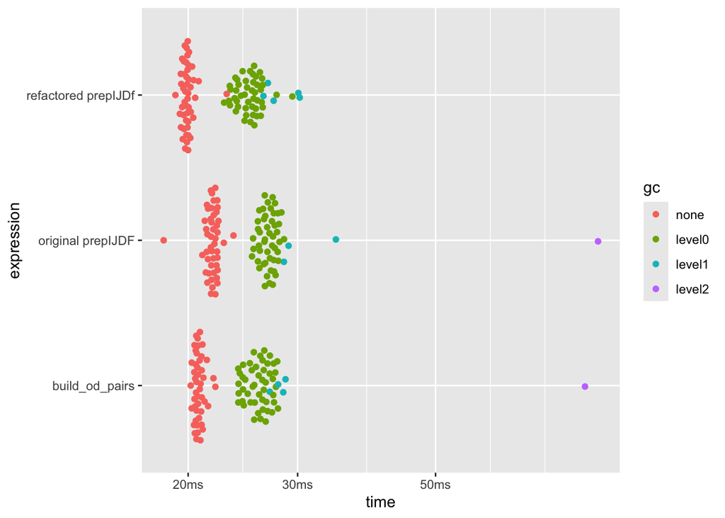

```r
plot(results)
```

# Testing

Test cases are in `00_warmup/tests/testthat`.

```r
setwd("~/GitHub_m-hutch/independent-study-su26")
source("00_warmup/tests/testthat.R")
```

```
## ✔ | F W  S  OK | Context
## ⠏ |          0 | build_od_pairs                                                 ⠙ |          2 | build_od_pairs                                                 ⠸ |         14 | build_od_pairs                                                 ⠇ |         29 | build_od_pairs                          …
## ⠏ |          0 | new_prepIJDf                                                   ⠇ |          9 | new_prepIJDf                                                   ⠴ |         16 | new_prepIJDf                                                   ⠧ |         28 | new_prepIJDf                            …
##
## ══ Results ═════════════════════════════════════════════════════════════════════
## [ FAIL 0 | WARN 0 | SKIP 0 | PASS 67 ]
##
## ══ DONE ════════════════════════════════════════════════════════════════════════
```

# Notes / Questions

Both functions follow the behavior of the original `prepIJDf` of centering and scaling the entire data frame, including the log-ratio columns, when `zTrans` is true (or `transform` is “standard” or “log.standard”). I’m not sure if this would always be the desired behavior, since scaling the log-ratio column makes it much more difficult to interpret.